# Model phát hiện bệnh trên lá cà chua by HungDang

```python
import tensorflow as tf
from tensorflow.keras import models, layers
import matplotlib.pyplot as plt
import pandas as pd
import warnings
warnings.filterwarnings('ignore')
```

### Cụ thể, các dòng code làm như sau:

- import tensorflow as tf: import thư viện TensorFlow
- from tensorflow.keras import models, layers: import các lớp và mô hình từ module keras trong TensorFlow
- import matplotlib.pyplot as plt: import thư viện matplotlib để trực quan hóa kết quả
- import pandas as pd: import thư viện pandas để phân tích kết quả
- import warnings: import module warnings để quản lý cảnh báo trong quá trình chạy chương trình
- warnings.filterwarnings('ignore'): bỏ qua tất cả các cảnh báo xuất hiện trong quá trình chạy chương trình. Câu lệnh này giúp cho quá trình huấn luyện được thực hiện mà không bị gián đoạn bởi các cảnh báo không quan trọng.
- Tóm lại, đoạn code trên import các thư viện cần thiết để xây dựng mô hình và phân tích kết quả, và thiết lập cấu hình để bỏ qua các cảnh báo không quan trọng trong quá trình chạy chương trình.

**Model constants

```python
BATCH_SIZE = 32
IMAGE_SIZE = 256
CHANNELS=3
EPOCHS=20
```

- BATCH_SIZE = 32: đây là kích thước của các batch (tập các mẫu dữ liệu được xử lý cùng lúc) được sử dụng trong quá trình huấn luyện. Khi huấn luyện mô hình, các mẫu dữ liệu sẽ được chia thành các batch với kích thước tương ứng và được truyền vào mô hình để cập nhật trọng số. Giá trị 32 là giá trị thông thường được sử dụng trong quá trình huấn luyện mô hình.
- IMAGE_SIZE = 256: đây là kích thước ảnh đầu vào (trong pixel) được sử dụng trong quá trình huấn luyện mô hình. Kích thước ảnh quyết định độ phân giải của ảnh đầu vào và ảnh hưởng đến hiệu suất của mô hình. Kích thước 256x256 là kích thước thông thường được sử dụng trong các bài toán phân loại ảnh.
- CHANNELS = 3: đây là số kênh màu của ảnh đầu vào, ở đây giá trị là 3 tương ứng với ảnh RGB (Red, Green, Blue). Khi một ảnh được đưa vào mô hình, ảnh sẽ được phân chia thành các kênh màu và mỗi kênh màu sẽ được xử lý độc lập.
- EPOCHS = 20: đây là số lần mà toàn bộ tập dữ liệu được huấn luyện qua mô hình. Trong quá trình huấn luyện, mô hình sẽ cập nhật trọng số của mình sau mỗi batch dữ liệu được truyền qua. Sau khi toàn bộ tập dữ liệu được huấn luyện qua mô hình, đó là một epoch. Giá trị 20 ở đây nói lên rằng mô hình sẽ được huấn luyện qua toàn bộ tập dữ liệu 20 lần. Số epoch cần sử dụng để huấn luyện mô hình phụ thuộc vào kích thước tập dữ liệu, loại bài toán và mô hình được sử dụng.

```python
df_train= "../input/tomatoleaf/tomato/train"
df_test= "../input/tomatoleaf/tomato/val"
```

### Đây là đường dẫn tới thư mục chứa tập huấn luyện và tập kiểm tra của bộ dữ liệu lá cà chua. Cụ thể:

- df_train là đường dẫn tới thư mục chứa tập huấn luyện (training set) của bộ dữ liệu. Đường dẫn này được trỏ tới địa chỉ "../input/tomatoleaf/tomato/train".
- df_test là đường dẫn tới thư mục chứa tập kiểm tra (validation set) của bộ dữ liệu. Đường dẫn này được trỏ tới địa chỉ "../input/tomatoleaf/tomato/val".

```python
dataset_train = tf.keras.preprocessing.image_dataset_from_directory(
    df_train,
    seed=123,
    shuffle=True,
    image_size=(IMAGE_SIZE,IMAGE_SIZE),
    batch_size=BATCH_SIZE
)


dataset_test = tf.keras.preprocessing.image_dataset_from_directory(
    df_test,
    seed=123,
    shuffle=True,
    image_size=(IMAGE_SIZE,IMAGE_SIZE),
    batch_size=BATCH_SIZE
)
```

```
Found 10000 files belonging to 10 classes.
```

[output not shown]

```
Found 1000 files belonging to 10 classes.
```

- tf.keras.preprocessing.image_dataset_from_directory là một hàm được sử dụng trong thư viện TensorFlow để tạo tập dữ liệu ảnh từ các tập tin trong thư mục. Trong đoạn code này, chúng ta sử dụng hàm này để tạo hai tập dữ liệu ảnh từ các thư mục chứa tập huấn luyện và tập kiểm tra của bộ dữ liệu lá cà chua.
- Cụ thể, dataset_train được tạo ra từ đường dẫn df_train trỏ tới thư mục chứa tập huấn luyện. Tham số seed được sử dụng để đảm bảo rằng tập huấn luyện sẽ được chia ngẫu nhiên một cách nhất định trong quá trình huấn luyện. Tham số shuffle=True được sử dụng để xáo trộn các mẫu ảnh trong tập dữ liệu huấn luyện. Tham số image_size=(IMAGE_SIZE, IMAGE_SIZE) được sử dụng để đặt kích thước ảnh đầu vào. Tham số batch_size=BATCH_SIZE được sử dụng để xác định kích thước của các batch ảnh được sử dụng trong quá trình huấn luyện.
- Tương tự, dataset_test được tạo ra từ đường dẫn df_test trỏ tới thư mục chứa tập kiểm tra. Các tham số đầu vào của hàm tf.keras.preprocessing.image_dataset_from_directory được thiết lập tương tự như dataset_train.

```python
class_names = dataset_train.class_names
class_names
```

```
['Tomato___Bacterial_spot',
 'Tomato___Early_blight',
 'Tomato___Late_blight',
 'Tomato___Leaf_Mold',
 'Tomato___Septoria_leaf_spot',
 'Tomato___Spider_mites Two-spotted_spider_mite',
 'Tomato___Target_Spot',
 'Tomato___Tomato_Yellow_Leaf_Curl_Virus',
 'Tomato___Tomato_mosaic_virus',
 'Tomato___healthy']
```

- class_names là một danh sách các nhãn lớp (class) trong tập dữ liệu huấn luyện, được trích xuất từ thuộc tính class_names của đối tượng dataset_train. Cụ thể, khi ta tạo đối tượng dataset_train bằng cách sử dụng hàm
- tf.keras.preprocessing.image_dataset_from_directory, class_names sẽ được tự động trích xuất từ tên các thư mục trong thư mục tập huấn luyện. Mỗi tên thư mục sẽ được coi là một nhãn lớp, và sẽ được lưu trữ trong danh sách class_names.

```python
for image_batch, labels_batch in dataset_train.take(1):
    print(image_batch.shape)
    print(labels_batch.numpy())
```

```
2023-02-18 15:10:13.877914: I tensorflow/compiler/mlir/mlir_graph_optimization_pass.cc:185] None of the MLIR Optimization Passes are enabled (registered 2)
```

```
(32, 256, 256, 3)
[5 0 0 2 3 6 6 4 6 4 0 3 4 0 1 5 7 5 2 8 3 6 8 3 2 4 0 7 8 6 1 5]
```

- Đoạn code này lấy một batch dữ liệu (gồm BATCH_SIZE ảnh và nhãn tương ứng) từ dataset_train và in ra kích thước của tensor chứa các ảnh trong batch (image_batch.shape) và danh sách các nhãn tương ứng (labels_batch.numpy()).
- Cụ thể, hàm dataset_train.take(1) được sử dụng để lấy một batch đầu tiên trong tập dữ liệu huấn luyện. image_batch sẽ là tensor 4 chiều chứa batch ảnh, với kích thước (BATCH_SIZE, IMAGE_SIZE, IMAGE_SIZE, CHANNELS) trong đó BATCH_SIZE là số lượng ảnh trong một batch, IMAGE_SIZE là kích thước của ảnh sau khi đã được resize, CHANNELS là số kênh màu của ảnh (3 trong trường hợp ảnh RGB).
- Còn labels_batch là tensor 1 chiều chứa các nhãn tương ứng với các ảnh trong image_batch. Hàm numpy() được sử dụng để chuyển đổi labels_batch sang kiểu dữ liệu numpy array và in ra danh sách các nhãn tương ứng.

```python
#image visulization
```

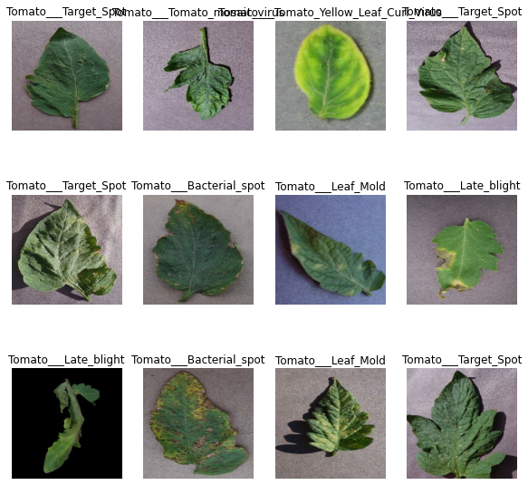

```python
plt.figure(figsize=(10, 10))
for image_batch, labels_batch in dataset_train.take(1):
    for i in range(12):
        ax = plt.subplot(3, 4, i + 1)
        plt.imshow(image_batch[i].numpy().astype("uint8"))
        plt.title(class_names[labels_batch[i]])
        plt.axis("off")
```

- Đoạn code này vẽ một grid ảnh có kích thước 3x4 (tổng cộng 12 ảnh) từ một batch dữ liệu đầu tiên trong tập huấn luyện (dataset_train). Mỗi ảnh được chọn từ image_batch và được gán nhãn tương ứng từ labels_batch.
- Cụ thể, hàm dataset_train.take(1) được sử dụng để lấy một batch đầu tiên trong tập dữ liệu huấn luyện. Mỗi ảnh trong batch được trích xuất và hiển thị trong một ô hình chữ nhật bằng cách sử dụng plt.imshow và gán nhãn tương ứng từ labels_batch. class_names được sử dụng để lấy tên của các lớp, được sắp xếp theo thứ tự từ 0 đến num_classes-1. Cuối cùng, hàm plt.axis("off") được sử dụng để ẩn trục tọa độ của các ảnh trong grid.

```python
#spliting the train part to both train and validation according ceartin ratio
```

```python
len(dataset_train)
```

```
313
```

```python
def get_dataset_partitions_tf(df,
                         train_split=0.8, val_split=0.2, shuffle=True, shuffle_size=10000):
    assert (train_split  + val_split) == 1

    ds_size = len(df)

    if shuffle:
        df= df.shuffle(shuffle_size, seed=12)

    train_size = int(train_split * ds_size)
    val_size = int(val_split * ds_size)

    train_ds =df.take(train_size)
    val_ds = df.skip(train_size).take(val_size)

    return train_ds, val_ds
```

- Hàm get_dataset_partitions_tf được sử dụng để phân chia tập dữ liệu thành tập huấn luyện và tập xác thực (validation set) dựa trên tỷ lệ cho trước (train_split và val_split). Tổng tỷ lệ của hai tập dữ liệu này phải bằng 1.
- Đầu vào của hàm là dataframe (df), tỷ lệ phân chia huấn luyện (train_split), tỷ lệ phân chia xác thực (val_split), cờ để bật hoặc tắt chức năng xáo trộn (shuffle) và kích thước của buffer được sử dụng để xáo trộn (shuffle_size).
- Hàm trả về hai dataset: train_ds và val_ds. Hàm sẽ lấy train_size bằng cách nhân tỷ lệ train_split với kích thước của dataframe. Tương tự, hàm sẽ lấy val_size bằng cách nhân tỷ lệ val_split với kích thước của dataframe. Sau đó, hàm sẽ sử dụng phương thức take và skip của dataframe để chia tập dữ liệu thành train_ds và val_ds.

```python
train_ds, val_ds = get_dataset_partitions_tf(dataset_train)
```

- Đoạn code trên sử dụng hàm get_dataset_partitions_tf để tách tập dữ liệu huấn luyện thành hai phần là tập huấn luyện và tập validation theo tỉ lệ train_split và val_split được cung cấp.
- Hàm get_dataset_partitions_tf nhận đầu vào là dataset df, tỉ lệ phân chia train_split và val_split, tham số shuffle cho biết có nên xáo trộn dữ liệu hay không và shuffle_size là kích thước để xáo trộn dữ liệu. Đầu ra của hàm là hai dataset train_ds và val_ds.
- Trong trường hợp này, hàm get_dataset_partitions_tf được sử dụng để chia tập huấn luyện dataset_train thành hai phần với tỉ lệ train_split=0.8 và val_split=0.2. Kết quả trả về là hai dataset train_ds và val_ds.

```python
len(train_ds)
```

```
250
```

```python
len(val_ds)
```

```
62
```

```python
train_ds = train_ds.cache().shuffle(1000).prefetch(buffer_size=tf.data.AUTOTUNE)
val_ds = val_ds.cache().shuffle(1000).prefetch(buffer_size=tf.data.AUTOTUNE)
dataset_test = dataset_test.cache().shuffle(1000).prefetch(buffer_size=tf.data.AUTOTUNE)
```

- Các dòng code này sử dụng các phương thức của tf.data.Dataset để tạo ra các bộ dữ liệu huấn luyện và kiểm tra, và lưu trữ các bộ dữ liệu này trong bộ nhớ cache để tăng tốc độ huấn luyện.
- Cụ thể, các dòng code này có các tác vụ sau:
1. train_ds.cache(): lưu trữ các mẫu dữ liệu huấn luyện trong bộ nhớ cache để tăng tốc độ đọc dữ liệu.
2. train_ds.shuffle(1000): xáo trộn các mẫu dữ liệu huấn luyện mỗi lần lặp lại để tránh ảnh hưởng của thứ tự dữ liệu đến quá trình huấn luyện.
3. train_ds.prefetch(buffer_size=tf.data.AUTOTUNE): tải các mẫu dữ liệu huấn luyện vào bộ nhớ trước khi cần thiết để tăng tốc độ đọc dữ liệu.
- Tương tự, các bộ dữ liệu kiểm tra và kiểm tra cũng được lưu trữ trong bộ nhớ cache và được sắp xếp để tăng tốc độ đọc dữ liệu.

```python
#keep size , normalize and data ogmantuation
data_scaling = tf.keras.Sequential([
  layers.experimental.preprocessing.Resizing(IMAGE_SIZE, IMAGE_SIZE),
  layers.experimental.preprocessing.Rescaling(1./255)
])
data_augmentation = tf.keras.Sequential([
  layers.experimental.preprocessing.RandomFlip("horizontal_and_vertical"),
  layers.experimental.preprocessing.RandomRotation(0.2),
  layers.experimental.preprocessing.RandomContrast(0.5),
  tf.keras.layers.experimental.preprocessing.RandomZoom(0.2),
  tf.keras.layers.experimental.preprocessing.RandomHeight(0.2),
  tf.keras.layers.experimental.preprocessing.RandomWidth(0.2)

])
```

```python
#now  let us apply data augmentation
train_ds = train_ds.map(
    lambda x, y: (data_augmentation(x, training=True), y)
).prefetch(buffer_size=tf.data.AUTOTUNE)
```

- Trong đoạn code trên, đang sử dụng phương thức map() để áp dụng data_augmentation trên tập huấn luyện train_ds. data_augmentation sử dụng các lớp xử lý ảnh để tạo ra các phiên bản tăng cường dữ liệu cho ảnh, nhằm giúp mô hình học được các đặc trưng quan trọng hơn và tránh overfitting.
- Hàm map() áp dụng một hàm lambda cho từng phần tử của train_ds, trong trường hợp này là lambda x, y: (data_augmentation(x, training=True), y). Hàm này sẽ áp dụng data_augmentation lên ảnh đầu vào x và trả về một cặp (data_augmentation(x, training=True), y), trong đó training=True để cho biết đây là tập huấn luyện.
- Cuối cùng, dùng prefetch() để tải dữ liệu cho bộ nhớ đệm trước khi cần thiết, giúp tăng tốc độ xử lý dữ liệu cho mô hình.

```python
input_shape = (BATCH_SIZE, IMAGE_SIZE, IMAGE_SIZE, CHANNELS)
n_classes = 10

model = models.Sequential([
    data_scaling,
  #  data_augmentation,
    layers.Conv2D(32, kernel_size = (3,3), activation='relu', input_shape=input_shape),
    layers.MaxPooling2D((2, 2)),
    layers.Conv2D(64,  kernel_size = (3,3), activation='relu'),
    layers.MaxPooling2D((2, 2)),
    layers.Conv2D(64,  kernel_size = (3,3), activation='relu'),
    layers.MaxPooling2D((2, 2)),
    layers.Conv2D(64, (3, 3), activation='relu'),
    layers.MaxPooling2D((2, 2)),
    layers.Conv2D(64, (3, 3), activation='relu'),
    layers.MaxPooling2D((2, 2)),
    layers.Conv2D(64, (3, 3), activation='relu'),
    layers.MaxPooling2D((2, 2)),
    layers.Flatten(),
    layers.Dense(64, activation='relu'),
    layers.Dense(n_classes, activation='softmax'),
])

model.build(input_shape=input_shape)
```

### Trong đoạn mã trên, đang xây dựng một mô hình mạng nơ-ron sâu (deep neural network) bằng thư viện keras của TensorFlow.

- data_scaling là một Sequential model chứa hai lớp để định hình kích thước đầu vào và chuẩn hoá giá trị pixel về khoảng [0, 1].
- n_classes là số lượng các lớp (classes) cần phân loại ở tầng đầu ra.
- model là một Sequential model chứa các lớp cần thiết để học các đặc trưng (features) của ảnh đầu vào và phân loại chúng vào các lớp tương ứng.
- Conv2D là lớp tích chập hai chiều dùng để tìm ra các đặc trưng của ảnh.
- MaxPooling2D là lớp dùng để giảm kích thước của đầu vào bằng cách lấy giá trị lớn nhất trong các vùng cửa sổ không trùng nhau của ảnh.
- Flatten là lớp dùng để duỗi các đặc trưng đã tìm được thành một vector để đưa vào các lớp kết nối đầy đủ (fully-connected layers) cuối cùng.
- Dense là lớp kết nối đầy đủ với số lượng đơn vị ở lớp cuối cùng bằng với n_classes, và hàm kích hoạt (activation function) ở lớp cuối cùng là softmax, để đưa ra xác suất của mỗi ảnh rơi vào từng lớp.
- Kích thước đầu vào của mô hình là (BATCH_SIZE, IMAGE_SIZE, IMAGE_SIZE, CHANNELS) với BATCH_SIZE là số lượng ảnh trong mỗi lần huấn luyện, IMAGE_SIZE là kích thước ảnh, CHANNELS là số kênh màu của ảnh (RGB là 3). Kích thước đầu ra của mô hình là (BATCH_SIZE, n_classes). Mô hình được xây dựng với input_shape là kích thước đầu vào.

```python
model.summary()
```

```
Model: "sequential_2"
_________________________________________________________________
Layer (type)                 Output Shape              Param #
=================================================================
sequential (Sequential)      (32, 256, 256, 3)         0
_________________________________________________________________
conv2d (Conv2D)              (32, 254, 254, 32)        896
_________________________________________________________________
max_pooling2d (MaxPooling2D) (32, 127, 127, 32)        0
_________________________________________________________________
conv2d_1 (Conv2D)            (32, 125, 125, 64)        18496
_________________________________________________________________
max_pooling2d_1 (MaxPooling2 (32, 62, 62, 64)          0
_________________________________________________________________
conv2d_2 (Conv2D)            (32, 60, 60, 64)          36928
_________________________________________________________________
max_pooling2d_2 (MaxPooling2 (32, 30, 30, 64)          0
_________________________________________________________________
conv2d_3 (Conv2D)            (32, 28, 28, 64)          36928
_________________________________________________________________
max_pooling2d_3 (MaxPooling2 (32, 14, 14, 64)          0
_________________________________________________________________
conv2d_4 (Conv2D)            (32, 12, 12, 64)          36928
_________________________________________________________________
max_pooling2d_4 (MaxPooling2 (32, 6, 6, 64)            0
_________________________________________________________________
conv2d_5 (Conv2D)            (32, 4, 4, 64)            36928
_________________________________________________________________
max_pooling2d_5 (MaxPooling2 (32, 2, 2, 64)            0
_________________________________________________________________
flatten (Flatten)            (32, 256)                 0
_________________________________________________________________
dense (Dense)                (32, 64)                  16448
_________________________________________________________________
dense_1 (Dense)              (32, 10)                  650
=================================================================
Total params: 184,202
Trainable params: 184,202
Non-trainable params: 0
_________________________________________________________________
```

Hàm model.summary() được sử dụng để hiển thị thông tin tóm tắt của mô hình đã được xây dựng bao gồm:

- Tên của các lớp mô hình
- Kích thước đầu vào và đầu ra của từng lớp
- Số lượng các tham số trong mỗi lớp
- Tổng số tham số trong mô hình

```python
model.compile(
    optimizer='adam',
    loss=tf.keras.losses.SparseCategoricalCrossentropy(from_logits=False),
    metrics=['accuracy']
)
```

Ở đoạn code này, đang thiết lập quá trình huấn luyện mô hình cho bộ dữ liệu.

- optimizer là thuật toán tối ưu hóa, ở đây ta chọn là 'adam', đây là thuật toán tối ưu hóa phổ biến được sử dụng trong Deep Learning. loss là hàm mất mát được sử dụng để đánh giá sự khác biệt giữa giá trị dự đoán và giá trị thực tế. Ở đây, ta sử dụng hàm mất mát SparseCategoricalCrossentropy để tính toán mất mát. metrics là chỉ số đánh giá hiệu suất mô hình. Ở đây đang sử dụng chỉ số accuracy để đánh giá hiệu suất của mô hình.

```python
history = model.fit(
    dataset_train,
    batch_size=32,
    #steps_per_epoch=len(dataset_test)// batch_size,
    validation_data=val_ds,
    verbose=1,
    epochs=EPOCHS,
)
```

```
2023-02-18 15:10:20.118112: I tensorflow/stream_executor/cuda/cuda_dnn.cc:369] Loaded cuDNN version 8005
```

[output not shown]

Trong đoạn code này, đang sử dụng phương thức fit để huấn luyện mô hình với dữ liệu từ dataset_train. Các thông số của phương thức được thiết lập như sau:

- batch_size: kích thước của mỗi batch dữ liệu được sử dụng trong quá trình huấn luyện.
- validation_data: tập dữ liệu validation.
- verbose: mức độ logging khi huấn luyện mô hình.
- epochs: số lần lặp lại quá trình huấn luyện. ### Kết quả của quá trình huấn luyện được lưu trong biến history.

```python
scores =model.evaluate(dataset_test)
```

- Đây là câu lệnh đánh giá hiệu suất của mô hình trên tập dữ liệu kiểm tra (test set). Các đánh giá này được sử dụng để đánh giá khả năng của mô hình trong việc phân loại ảnh trên tập dữ liệu chưa được huấn luyện.
- Các đánh giá được thực hiện bằng phương pháp "đánh giá đầu ra" (output evaluation) và bao gồm 2 thông số là "loss" và "accuracy". Thông số "loss" là một số thực cho biết mức độ lỗi của mô hình trên tập dữ liệu kiểm tra, càng thấp thì mô hình càng tốt. Thông số "accuracy" là tỷ lệ phần trăm của các ảnh được phân loại đúng trên tổng số ảnh kiểm tra. Càng cao thì mô hình càng tốt.
- Câu lệnh scores = model.evaluate(dataset_test) sẽ trả về giá trị của loss và accuracy của mô hình trên tập dữ liệu kiểm tra và gán chúng vào biến scores.

```python
scores
```

```
[0.5026522874832153, 0.875]
```

```python
history.params
```

```
{'verbose': 1, 'epochs': 20, 'steps': 313}
```

```python
history.history.keys()
```

```
dict_keys(['loss', 'accuracy', 'val_loss', 'val_accuracy'])
```

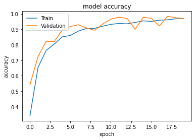

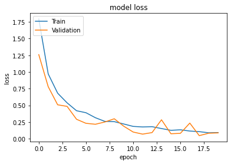

```python
# summarize history for accuracy
plt.plot(history.history['accuracy'])
plt.plot(history.history['val_accuracy'])
plt.title('model accuracy')
plt.ylabel('accuracy')
plt.xlabel('epoch')
plt.legend(['Train', 'Validation'], loc='upper left')
plt.show()
# summarize history for loss
plt.plot(history.history['loss'])
plt.plot(history.history['val_loss'])
plt.title('model loss')
plt.ylabel('loss')
plt.xlabel('epoch')
plt.legend(['Train', 'Validation'], loc='upper left')
plt.show()
```

- Sau khi huấn luyện mô hình,sử dụng lịch sử của quá trình huấn luyện để trực quan hóa độ chính xác và độ lỗi trên tập huấn luyện và tập kiểm tra. Đầu tiên, chúng ta sử dụng history.history['accuracy'] và history.history['val_accuracy'] để truy xuất độ chính xác trên tập huấn luyện và tập kiểm tra tương ứng trong suốt quá trình huấn luyện. Sau đó, chúng ta sử dụng plt.plot để vẽ đồ thị độ chính xác của mô hình trên tập huấn luyện và tập kiểm tra theo các epoch.
- Tương tự, chúng ta sử dụng history.history['loss'] và history.history['val_loss'] để truy xuất độ lỗi trên tập huấn luyện và tập kiểm tra trong suốt quá trình huấn luyện. Sau đó, chúng ta sử dụng plt.plot để vẽ đồ thị độ lỗi của mô hình trên tập huấn luyện và tập kiểm tra theo các epoch.

```
first image to predict
actual label: Tomato___Spider_mites Two-spotted_spider_mite
predicted label: Tomato___Spider_mites Two-spotted_spider_mite
```

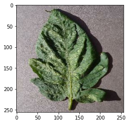

```python
#Run the predication on the first image
import numpy as np
for images_batch, labels_batch in dataset_test.take(1):

    first_image = images_batch[0].numpy().astype('uint8')
    first_label = labels_batch[0].numpy()

    print("first image to predict")
    plt.imshow(first_image)
    print("actual label:",class_names[first_label])

    batch_prediction = model.predict(images_batch)
    print("predicted label:",class_names[np.argmax(batch_prediction[0])])
```

- Trong đoạn code này, ta đang lấy ra một batch gồm các ảnh và nhãn tương ứng từ tập dataset_test. Sau đó, ta lấy ảnh đầu tiên trong batch đó để dự đoán nhãn.
- Đầu tiên, ta chuyển đổi ảnh đầu tiên từ dạng tensor về dạng numpy và chuyển về kiểu dữ liệu uint8 để có thể hiển thị bằng hàm plt.imshow(). Sau đó, ta lấy nhãn tương ứng với ảnh đầu tiên trong batch và hiển thị lên màn hình.
- Tiếp theo, ta sử dụng mô hình đã huấn luyện để dự đoán nhãn cho toàn bộ batch và lấy ra kết quả dự đoán của ảnh đầu tiên trong batch đó. Cuối cùng, ta in ra nhãn dự đoán được và so sánh với nhãn thực tế để kiểm tra độ chính xác của mô hình.

```
first image to predict
actual label: Tomato___Spider_mites Two-spotted_spider_mite
predicted label: Tomato___Spider_mites Two-spotted_spider_mite
```

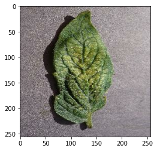

```python
for images_batch, labels_batch in dataset_test.take(1):

    first_image = images_batch[0].numpy().astype('uint8')
    first_label = labels_batch[0].numpy()

    print("first image to predict")
    plt.imshow(first_image)
    print("actual label:",class_names[first_label])

    batch_prediction = model.predict(images_batch)
    print("predicted label:",class_names[np.argmax(batch_prediction[0])])
```

```
first image to predict
actual label: Tomato___Tomato_mosaic_virus
predicted label: Tomato___Tomato_mosaic_virus
```

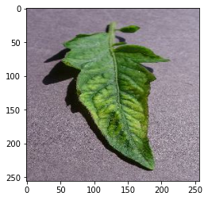

```python
for images_batch, labels_batch in dataset_test.take(1):

    first_image = images_batch[0].numpy().astype('uint8')
    first_label = labels_batch[0].numpy()

    print("first image to predict")
    plt.imshow(first_image)
    print("actual label:",class_names[first_label])

    batch_prediction = model.predict(images_batch)
    print("predicted label:",class_names[np.argmax(batch_prediction[0])])
```

```
first image to predict
actual label: Tomato___Tomato_Yellow_Leaf_Curl_Virus
predicted label: Tomato___Tomato_Yellow_Leaf_Curl_Virus
```

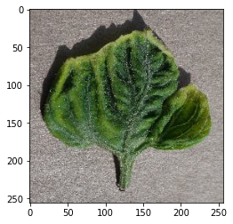

```python
for images_batch, labels_batch in dataset_test.take(1):

    first_image = images_batch[0].numpy().astype('uint8')
    first_label = labels_batch[0].numpy()

    print("first image to predict")
    plt.imshow(first_image)
    print("actual label:",class_names[first_label])

    batch_prediction = model.predict(images_batch)
    print("predicted label:",class_names[np.argmax(batch_prediction[0])])
```

```python
# Lưu mô hình
model.save('my_model.h5')

# Tải mô hình
loaded_model = tf.keras.models.load_model('my_model.h5')
```

```
first image to predict
actual label: Tomato___Leaf_Mold
predicted label: Tomato___Leaf_Mold
```

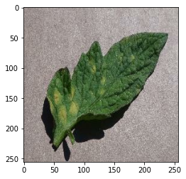

```python
for images_batch, labels_batch in dataset_test.take(1):

    first_image = images_batch[0].numpy().astype('uint8')
    first_label = labels_batch[0].numpy()

    print("first image to predict")
    plt.imshow(first_image)
    print("actual label:",class_names[first_label])

    batch_prediction = loaded_model.predict(images_batch)
    print("predicted label:",class_names[np.argmax(batch_prediction[0])])
```

```python
def predict_image(image_path, model):
    # Đọc hình ảnh từ file và chuyển đổi thành tensor
    img = tf.keras.preprocessing.image.load_img(image_path, target_size=(IMAGE_SIZE, IMAGE_SIZE))
    img_array = tf.keras.preprocessing.image.img_to_array(img)
    img_tensor = tf.keras.preprocessing.image.smart_resize(img_array, (IMAGE_SIZE, IMAGE_SIZE))
    img_tensor = tf.expand_dims(img_tensor, axis=0)

    # Dự đoán nhãn của hình ảnh
    prediction = model.predict(img_tensor)
    predicted_class = np.argmax(prediction[0])

    return class_names[predicted_class]
```

- Đây là một hàm để dự đoán nhãn của một hình ảnh bằng cách sử dụng mô hình đã huấn luyện. Đầu vào của hàm là đường dẫn đến tệp hình ảnh cần dự đoán và mô hình đã huấn luyện.
- Hàm bắt đầu bằng cách đọc hình ảnh từ tệp và chuyển đổi nó thành tensor. Sau đó, tensor được mở rộng để có một chiều đại diện cho số lượng ảnh (ở đây chỉ có một ảnh), và sau đó được truyền vào mô hình để dự đoán nhãn. Cuối cùng, hàm trả về tên lớp tương ứng với nhãn được dự đoán.

```python
image_path = "/input/tomatoleaf/tomato/val/Tomato___Early_blight/00c5c908-fc25-4710-a109-db143da23112___RS_Erly.B 7778.JPG"
predict_image(image_path, loaded_model)
```

```
'Tomato___Early_blight'
```